# Rubicon Project Data Scientist Interview

Trevor Barrett

August 9th, 2019

# Take Home Exercise Instructions

#### Problem Statement

> There are three columns in the data table - key, x and y. The graph shows that beyond a certain point a change in x, y reaches a point of diminishing return. How would you analyze this data and determine diminishing returns using an automated algorithm(aka build prototype)? Articulate your assumptions, and reasons for picking the point of diminishing return.

#### Bonus Points

> Check if your algorithm is generic enough across the entire data set and show a visual that proves it is generic. Add a business context where this kind of problem is applicable

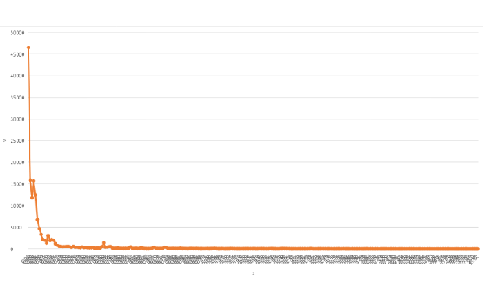

Original Excel plot showing diminishing return function in data collapsed over all Keys.

# Solution Introduction

### Restatement of Problem

Determine the point of diminishing returns (PDR) for the supplied data set in using an automated algorithm.

- Definition from instructions: “beyond a certain point a change in x, y reaches a point of diminishing return”

In other words: Determine the inflection point of the function – where it begins to get increasingly difficult to achieve returns for each unit input.

### Data Characteristics

The data have an x and y variable, in addition a Key variable represented by a 16 digit string.

- Presumably, we will want to analyze the data at the level of individual Keys. The Key values are nominal and can be thought of as unique identifiers for each account, user, campaign, etc.
- Original Excel plot collapsed over the Key values – the putative grouping variable
  - Generated plots and analyses should reflect distinct Key groupings

### Articulation of Assumptions

We want to determine the PDR for each named Key ID in the data set. The point of diminishing return will be defined as the x-value were y begins to asymptote. Analysis should be broken down by individual Key – different data generating processes should be modeled separately. Further, calculating separate points of diminishing returns for each Key allows for modeling idosyncratic or biased behaviors. The end product of this exercise is a function that will automatically output the PDR x-value for each unique Key.

# Solution Walk-Through

## Outline

1. Data Import
2. Summarize Data
   - Descriptive stats
   - By Key
3. Data Exploration
   - Visual of all data
   - Visual By Key
   - Top 6 most-frequent Keys
   - Reparameterized visual to cumulative return y over input x
   - Visual of cumulative returns for each Key, grouped by total returns ranking
4. Algorithm Prototype
   - Visualization of Empirical Cumulative Density Function
   - Calculate ECDF and extract median x-value for each Key – the point of diminishing returns

## Data import

Here I’ll import the excel spreadsheet and view the data frame. The variables include Key, x, and y. Key is encoded as a text variable, and x and y are encoded as doubles.

```r
(df <-
  read_excel(
    "~/Downloads/Data_Scientist_Interview-Data_File.xlsx",
    col_types = c("text", "numeric", "numeric")
  ))
```

| Key | x | y |
| --- | --- | --- |
| 82353292333796 | 0.01 | 46531 |
| 82353292333796 | 0.02 | 15815 |
| 82353292333796 | 0.03 | 11814 |
| 82353292333796 | 0.04 | 15683 |
| 82353292333796 | 0.05 | 12484 |
| 82353292333796 | 0.06 | 6722 |
| 82353292333796 | 0.07 | 4655 |
| 82353292333796 | 0.08 | 3341 |
| 82353292333796 | 0.09 | 2138 |
| 82353292333796 | 0.10 | 1979 |

[output cut: 990 more lines]

[output not shown]

## Summarize Data

Get a general idea of the shape the distribution of each variable.

```r
df%>%
  summary()
```

```
     Key                  x                  y
 Length:161681      Min.   :   0.010   Min.   :    0.00
 Class :character   1st Qu.:   1.890   1st Qu.:    0.00
 Mode  :character   Median :   4.300   Median :    1.00
                    Mean   :   9.195   Mean   :   24.27
                    3rd Qu.:   9.600   3rd Qu.:    4.00
                    Max.   :1034.390   Max.   :46531.00
```

### By Key

- There were 173 unique Key values in the data.
- Each Key ranges in number of appearances from *n* = 5 to *n* = 5897.
- The average number of appearances was *mean* = 935.

Compute and print summary of data aggreggated by Key:

```r
(df_k<-df%>%
  group_by(Key)%>%
  summarise(n=n(), min(x), max(x), mean(x), min(y), max(y), sum(y))%>%
  arrange(desc(n,`sum(y)`)))
```

| Key | n | min(x) | max(x) | mean(x) | min(y) | max(y) | sum(y) |
| --- | --- | --- | --- | --- | --- | --- | --- |
| 3.39263436386599E+16 | 5897 | 0.79 | 128.00 | 5.1427285 | 0 | 685 | 13995 |
| 3.23633478887313E+16 | 5707 | 0.20 | 100.00 | 23.9431365 | 0 | 1115 | 37239 |
| 3.23633478686986E+16 | 4098 | 0.20 | 135.39 | 5.5535822 | 0 | 3261 | 102726 |
| 3.23633478326985E+16 | 3083 | 0.20 | 100.00 | 15.2571651 | 0 | 1821 | 37239 |
| 3.36263828284839E+16 | 3071 | 0.18 | 100.00 | 11.9528264 | 0 | 377 | 23490 |
| 3.33663829684838E+16 | 3022 | 0.63 | 189.24 | 6.1777598 | 0 | 5295 | 134217 |
| 3.53823357946463E+16 | 2987 | 0.45 | 612.16 | 26.0988818 | 0 | 25003 | 320307 |
| 3.32583357666513E+16 | 2947 | 0.18 | 1034.39 | 8.9495691 | 0 | 1934 | 44255 |
| 3325878942518930 | 2825 | 0.35 | 618.19 | 22.3239186 | 0 | 7256 | 96407 |
| 3.32583357666557E+16 | 2730 | 0.18 | 620.64 | 7.3599670 | 0 | 2285 | 35319 |

[output cut: 163 more lines]

[output not shown]

## Data Exploration

Examples of various visualization techniques that are useful for getting to know the data set during the exploration phase.

### Overall Plot (all data points)

Here the log1p `log10(x+1)` transformed axes and reduced point alpha help to produce a more interpretable plot of all of the data at once. The blue line represents the smoothing function using method = ‘gam’ and formula:

```
y ~ s(x, bs = "cs")
```

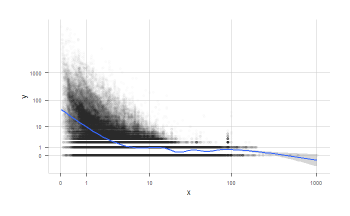

```r
df %>%
  arrange(Key, x, y)%>%
  ggplot(aes(x, y)) +
  geom_point(alpha=.01)+
  scale_x_continuous(trans="log1p", breaks = c(0,1,10,100,1000))+
  scale_y_continuous(trans="log1p", breaks = c(0,1,10,100,1000))+
  geom_smooth()
```

#### Colored by Key

Plot with distinct Keys denoted by discrete color palette.

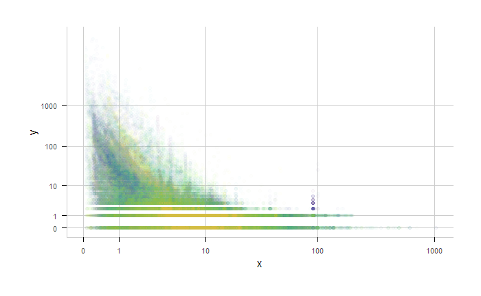

```r
df%>%
  arrange(Key, x, y)%>%
  ggplot(aes(x,y,color=Key))+
  geom_point(alpha = .01)+
  scale_x_continuous(trans="log1p", breaks = c(0,1,10,100,1000))+
  scale_y_continuous(trans="log1p", breaks = c(0,1,10,100,1000))+
  theme(legend.position = "none")+
  scale_color_viridis_d()
```

Here we can clearly see how the Keys shown in separate colors have different diminishing rates of return x-values.

### Plot from top 6 Keys

These Keys had the most individual observations, each with over 3000.

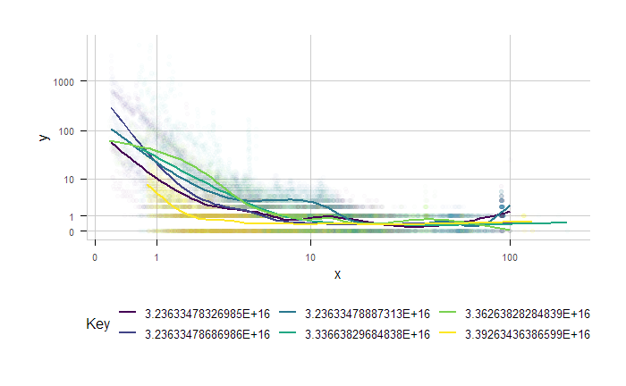

```r
df %>%
  arrange(Key, x, y)%>%
  add_count(Key)%>%
  filter(n>3000)%>%
  ggplot(aes(x, y, group = Key)) +
  geom_point(alpha=.01, aes(color = Key))+
  scale_x_continuous(trans="log1p", breaks = c(0,1,10,100,1000))+
  scale_y_continuous(trans="log1p", breaks = c(0,1,10,100,1000))+
  scale_color_viridis_d()+
  geom_smooth(aes(color = Key), se = F)
```

This visual is more interpretable than the previous, but it would be helpful if we reparameterized the scales to reflect the cumulative sum of y returns.

#### Cumulative Sum Plot

This plots the cumulative sum of y for each value x.

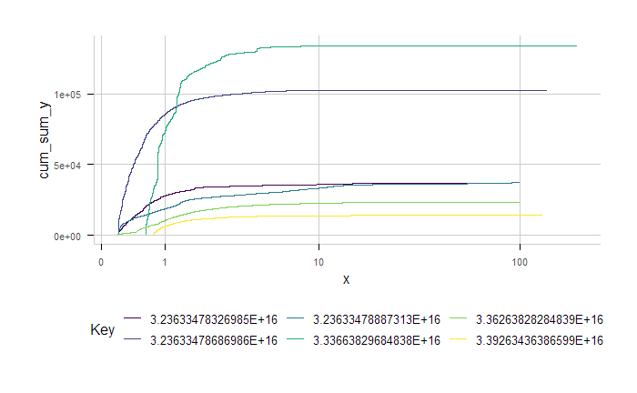

```r
df%>%
  arrange(Key, x, y)%>%
  add_count(Key)%>%
  filter(n>3000)%>%
  group_by(Key)%>%
  mutate(n_obs = row_number(),
         cum_sum_y = cumsum(y),
         y_next = abs(y - lead(y)))%>%
  ggplot(aes(x, cum_sum_y, color = Key))+
  geom_path()+
  scale_color_viridis_d()+
  scale_x_continuous(trans="log1p", breaks = c(0,1,10,100,1000))
```

We can see that the location at which each Key’s line asymptotes represents point of diminishing returns – increasing x input has exponentially less impact on y output.

### Individual cumulative sum plot of all data

This plot displays the cumulative sum of y values over x, with separate lines for each Key. The panels are faceted by the ntile (9) of the maximum y value for each Key. For example, Keys in panel 1 had the lowest total returns, while those in panel nine yielded the highest total returns.

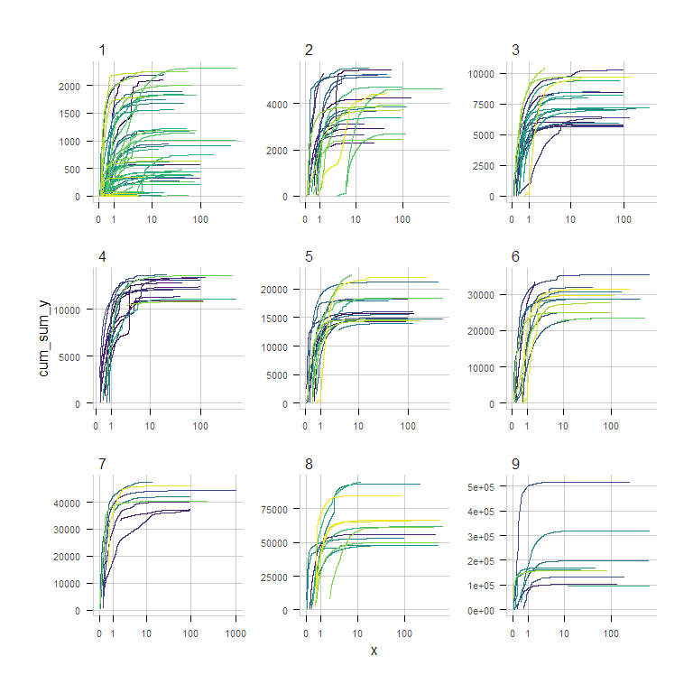

```r
df%>%
  add_count(Key)%>%
  group_by(Key)%>%
  arrange(Key, x, y)%>%
  mutate(n_obs = row_number(),
         cum_sum_y = cumsum(y),
         last_y = y - lead(y),
         max_y = max(cum_sum_y))%>%
  ungroup()%>%
  mutate(quant = ntile(max_y, 9))%>%
  ggplot(aes(x, cum_sum_y, color = Key))+
  geom_path()+
  scale_color_viridis_d()+
  scale_x_continuous(trans="log1p", breaks = c(0,1,10,100,1000))+
  theme(legend.position = "none")+facet_wrap(~quant, scales = "free")
```

The diminishing return point for each Key function is the x value of the y asymptote. Visual inspection of the plot reveals the range of diminishing return points to be between 1-10 for the upper ntiles, and less than 1 for the Keys with the lowest cum_sum_y.

## Algorithm Prototype

Here we will calculate the Empirical Cumulative Density Function for each Key. The x-value at the ECDF median represents the point of diminishing returns. First we will plot the ECDF of each Key so we can visually verify that the cumulative diminishing returns distribution function intersects the y axis at .5.

### Visualization

This is the visual of of an automated method for determining points of diminishing return in a general way applied to the entire data set.

#### Cumulitive probability plots faceted by 9tile of max_y

Displaying the cumulative probability of the distributions will be helpful for visually identifying the point of diminishing returns. Here, the .50 cumulative probability line should intersect the x-value of where returns will have a 50% chance of diminishing.

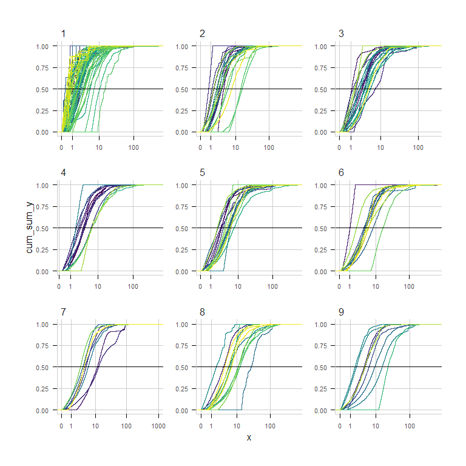

```r
df%>%
  arrange(Key, x, y)%>%
  add_count(Key)%>%
  group_by(Key)%>%
  mutate(n_obs = row_number(),
         cum_sum_y = cumsum(y),
         last_y = y - lead(y),
         max_y = max(cum_sum_y))%>%
  ungroup()%>%
      mutate(quant = ntile(max_y, 9))%>%
  ggplot(aes(x, cum_sum_y, color = Key))+
  stat_ecdf()+
  theme(legend.position = "none")+
  scale_x_continuous(trans="log1p", breaks = c(0,1,10,100,1000))+
  facet_wrap(~quant, scales = "free")+
  scale_color_viridis_d()+
  geom_hline(yintercept =.5)
```

The x-value of where each Key line intersects the median cumulative probability line represents the point at which increasing the x value will have a 50/50 chance of diminishing returns.

### Calculate Empirical CDF for each Key

Diminishing returns begin at the median x-value of the Empirical Cumulative Density Function. The following command will output the median x-value of the ECDF for each Key:

```
map(lapply(split(df$x, df$Key), ecdf), summary)
```

#### Extracting point of diminishing returns from ECDF

The point of diminishing returns is at the x-value of of the median ECDF. Here is a sample single-Key output summary from the ECDF.

```r
map(lapply(split(df$x, df$Key), ecdf), summary)[1]
```

```
$`3.23633476686976E+16`
Empirical CDF:    488 unique values with summary
   Min. 1st Qu.  Median    Mean 3rd Qu.    Max.
  0.500   1.718   3.050   4.221   4.662  58.850
```

## Points of diminishing return for each Key

In our case, we were only interested in determining the point of diminishing returns, so the following code is used to apply, extract, and gather the PDR from the median ECDF value from each Key.

```r
(PDR<-map_df(lapply(split(df$x, df$Key), ecdf), summary)[3,]%>%gather("Key","PDR"))
```

| Key | PDR |
| --- | --- |
| 3.23633476686976E+16 | 3.050 |
| 3.23633476687334E+16 | 3.775 |
| 3.23633476687358E+16 | 3.545 |
| 3.23633476687363E+16 | 2.610 |
| 3.23633476787318E+16 | 3.920 |
| 3.23633476866977E+16 | 3.025 |
| 3.23633476867341E+16 | 4.325 |
| 3.23633476966977E+16 | 2.515 |
| 3.23633476967341E+16 | 2.655 |
| 3.23633477926983E+16 | 3.615 |

[output cut: 163 more lines]

[output not shown]

```r
PDR%>%summary()
```

```
     Key                 PDR
 Length:173         Min.   : 0.290
 Class :character   1st Qu.: 1.920
 Mode  :character   Median : 3.415
                    Mean   : 4.204
                    3rd Qu.: 5.475
                    Max.   :18.785
```

# Business Application

I am thinking about an example in the context of search and pricing metrics for an ad-exchange marketplace. In this case the x-value could represent a computed distance score from a user’s desired ad requirements, and the y-value could represent the price paid to the exchange. An increased distance score (x) pushes down both the likelihood and price of sales past the point of diminishing returns, as can be observed by the shrinking increase in y-values past the median of the Empirical CDF.